# Biodiversity

Scott Pitz

November 21, 2017

## Goals for this script and assignment

- Get used to dealing with a larger data set
- Adjust a plot using some new techniques

Lets get going!

### 1. Data

This data is from two tree surveys on Barro Colorado Island in Panama. The Smithsonian owns the island and it’s in the middle of the Panama canal.

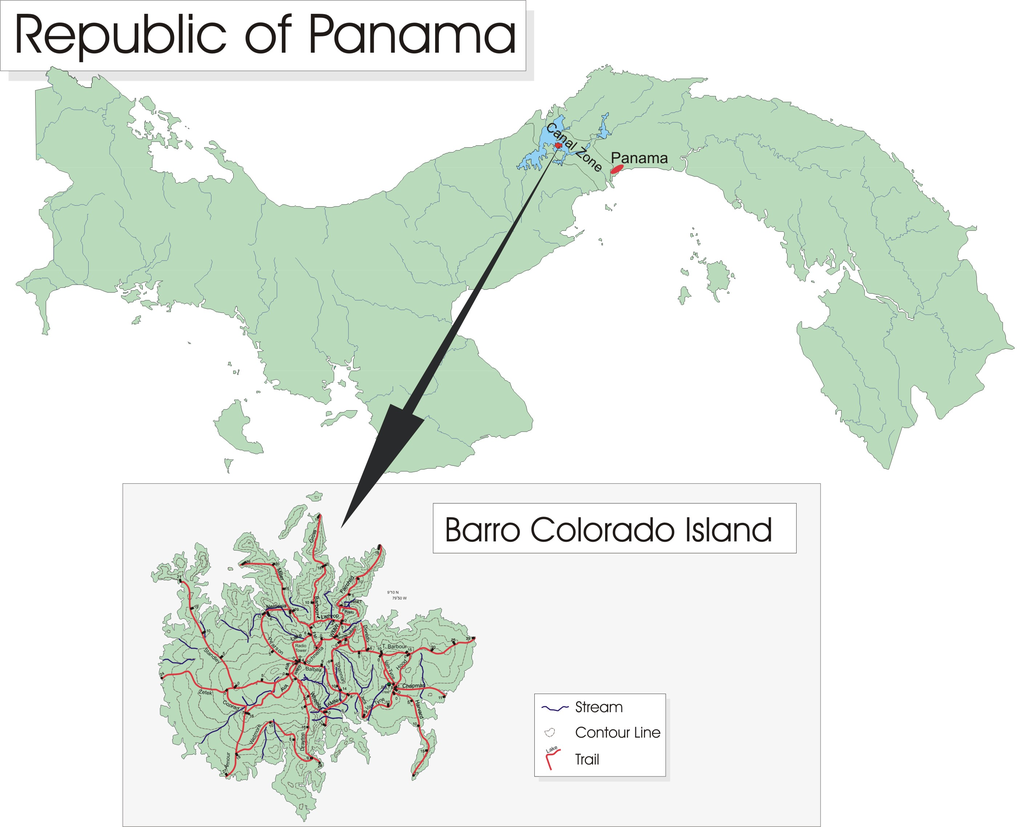

As you can probably guess, its a tropical rainforest. The data contains information about the location of each tree, the DBH (you should remember that from the field trip), the species, and several other parameters. There are two data files, one from 1982 and one from 2015.

Download the data files into the same directory as your R script will be located. I’ve placed a CSV file in a folder on the Blackboard page.

Link to E-Learning page - https://elearning.villanova.edu

Lets start the code as usual, with our normal clearing statement, load ggplot, and set our working directory. Uncomment the **setwd()** line as needed.

```r
# Clear workspace

rm(list=ls(all=T))

#this loads a package that has already been installed
library(ggplot2)
#set your working directory for your computer
setwd("C:/Users/Pitz/Documents/GitHub/TreePlot/") #pc format
#setwd("/Users/Your Name/Desktop/") #mac format

BCIData_1982 <- read.csv("BCI_PlotDataReport1982.csv") # read csv
BCIData_2015 <- read.csv("BCI_PlotDataReport2015.csv") # read csv
#head(BCIData_1982)
colnames(BCIData_1982)
```

```
##  [1] "No."        "Latin"      "Mnemonic"   "SubSpecies" "Quadrat"
##  [6] "PX"         "PY"         "TreeID"     "Tag"        "StemID"
## [11] "StemTag"    "Census"     "DBH"        "HOM"        "Date"
## [16] "Codes"      "Stem"       "Status"
```

#### Metadata and information

Metadata is the data about your data. Where it came from, what the codes mean, the units of a column, etc.

The units for the x and y columns are meters. DBH is in millimeters.

#### Length of a column

This is a larger data set than we have seen before in class. We can check how long our data set is or how many values in a column by using the **length** command. It returns the number of values/rows in that column. It should be 263,934.

```r
length(BCIData_1982$PX)
```

```
## [1] 263934
```

### Plot up tree locations

Now, we are essentially going to make a map.

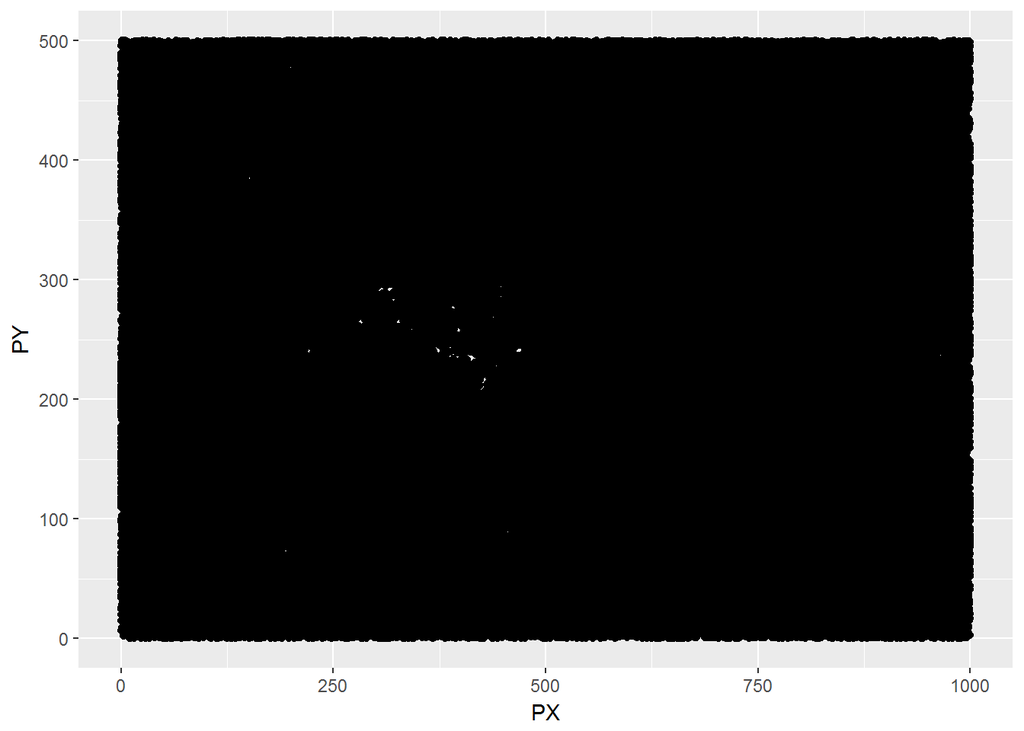

```r
TreeScatter <- ggplot(BCIData_1982, aes(PX, PY))
TreeScatter + geom_point()
```

### Fix the Aspect Ratio

Whoa, that’s a bunch of points. We have a couple options to try and make a nicer map using this data:

1. Fix the aspect ratio
2. Make the **geom_point()** smaller
3. Change the opacity/transparency of the points

This plot offends my, albeit weak, sense of style and aesthetics. It’s not proportioned. And since this is a basically a map, we shouldn’t distort it unless it’s necessary. Let’s also switch over to **theme_bw()**.

You need to fix it. Google “ggplot2 aspect ratio” to find the answer, or just look below… and make it look like this:

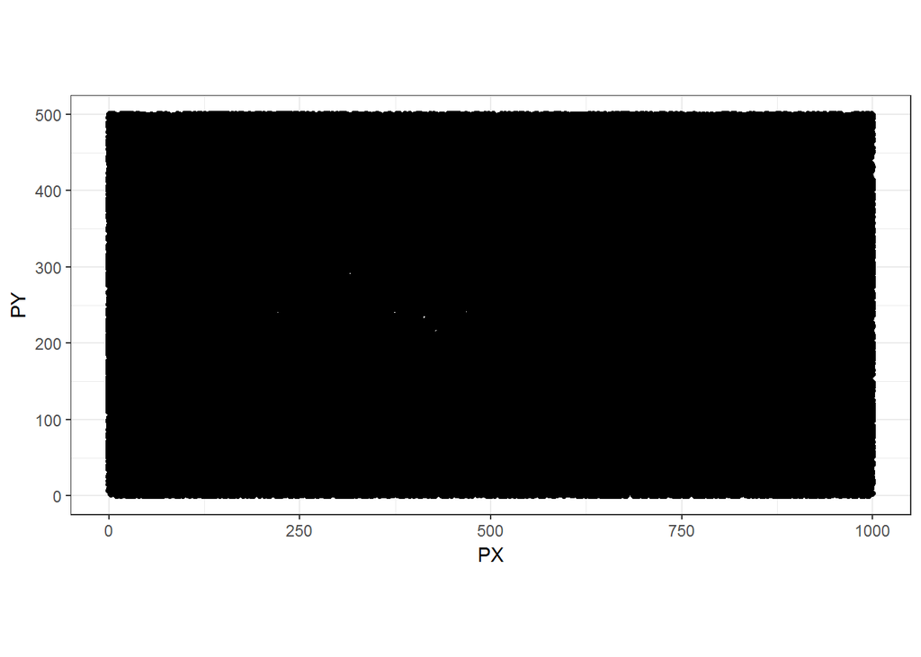

```r
TreeScatter + geom_point() + coord_fixed() + theme_bw()
```

### Make the points smaller

Ahhh, everything is right again. Nice and square

But, still no dice. We can’t really see anything of note. We can try making the points smaller than the default setting. We will add the aspect ratio and theme to the ggplot object and try a smaller point size.

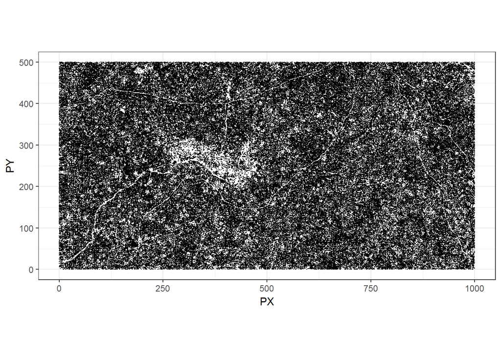

```r
TreeScatter <- TreeScatter + coord_fixed() + theme_bw()
TreeScatter + geom_point(size=0)
```

### Change the opacity

Just a general comment; some of you have mentioned about how much data your projects might be collecting. This code just plotted up over 200,000 points and seems not to be getting too bogged down.

So now we can see quite a bit of information. You can see streams or paths where no trees are going. Lets see if we can change the opacity of the points which is controlled by the option **alpha**.

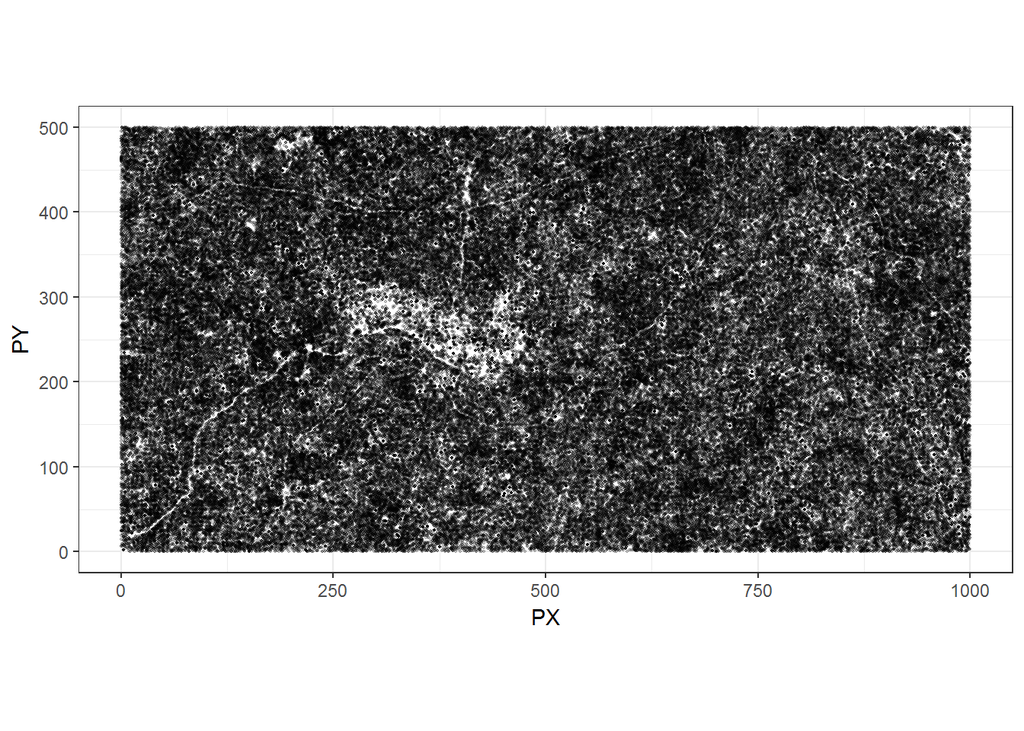

```r
TreeScatter <- TreeScatter + coord_fixed() + theme_bw()
TreeScatter + geom_point(size=0.4, alpha = 0.2)
```

Hopefully you can get a sense of how you can toggle the size and opacity to be able to see the patterns you are looking for. You can especially use the opacity/alpha to look at the density if points on a plot.

### Plot up Tree Species

We can add some code so that each point’s color is based on that trees species. It will help us start to get a sense of the breakdown and the spatial distribution of species in this forest.

We need to remove the legend.

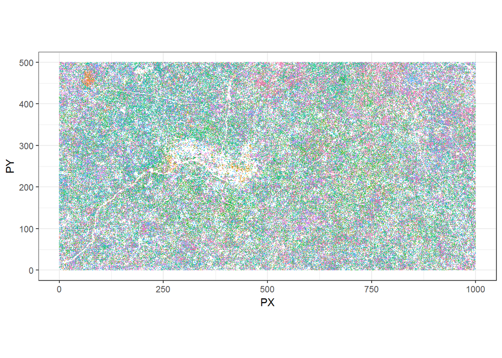

```r
TreeScatter + geom_point(size=0, alpha = 0.4, aes(colour = factor(Latin)))+
  theme(legend.position="none")
```

### Add DBH to Plot

Ok, last one for now.

Lets just look at the large trees and where they are located.

we can limit the number of trees in the plot to large ones and add a size variable to the point.

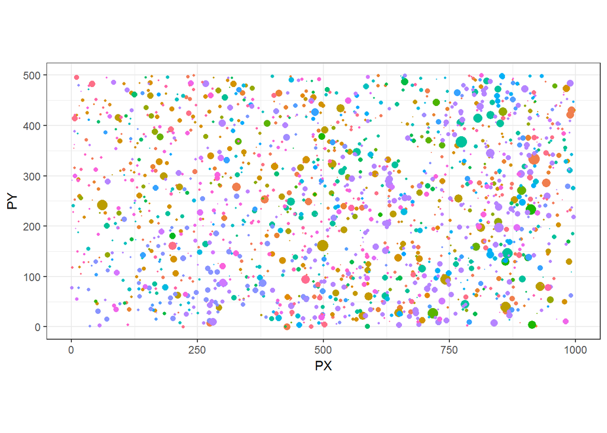

```r
BCIData_1982_Large <-  BCIData_1982[BCIData_1982$DBH > 500,]

TreeScatterBig <- ggplot(BCIData_1982_Large, aes(PX, PY))+
  geom_point(aes(colour = factor(Latin), size=DBH)) +
  scale_size_continuous(range = c(0,4))+
  coord_fixed() +
  theme_bw()+
  theme(legend.position="none")
TreeScatterBig
```